Summer Institute 2026 · Day 5

# Responsible AI & Future Directions

Using these tools well: fairness, privacy, accountability, community, and the environmental and societal stakes.

D. Alex Quistberg, PhD, MPH · Associate Research Professor  
An Introduction to AI for Urban Health Research & Practice

Overview

### Today's Lecture

The hard parts: making AI fair, private, accountable, community-grounded, and sustainable — in urban-health contexts.

Part 1

Bias & Fairness

Where bias enters, who it harms, and how to mitigate it.

Part 2

Privacy, Transparency & Accountability

Re-identification, the black box, model cards, and responsibility.

Part 3

Community Co-Design

A case study: climate & health in Bogotá and Barranquilla.

Part 4

Environment & the Future

AI's footprint, sustainability, and what's coming.

Objectives

### Learning Objectives

- Identify sources of bias in AI and strategies to mitigate them.
- Apply privacy, transparency, and accountability principles to health data.
- Document AI systems with model cards and datasheets.
- Explain why and how to involve communities in AI development.
- Weigh AI's environmental costs and the societal risks ahead.

Part 1

## Bias & Fairness

AI learns from data — including our historical inequities. In urban health, that can widen the gaps we aim to close.

Foundations

### AI Ethics & the FAIR Principles

#### Why ethics matters here

- Health decisions affect lives and equity
- Models can encode and scale existing bias
- Affected communities are often the least consulted

#### FAIR data

- **F**indable, **A**ccessible, **I**nteroperable, **R**eusable
- Good data stewardship underpins trustworthy AI
- Document provenance, licensing, and limits

Responsible AI starts upstream — with the data, not just the model.

FAIR: [go-fair.org](https://www.go-fair.org/fair-principles/) · [Wilkinson et al. (Sci Data)](https://www.nature.com/articles/sdata201618) · [AI ethics in health (npj)](https://www.nature.com/articles/s41746-023-00913-9)

Bias

### Where Bias Enters

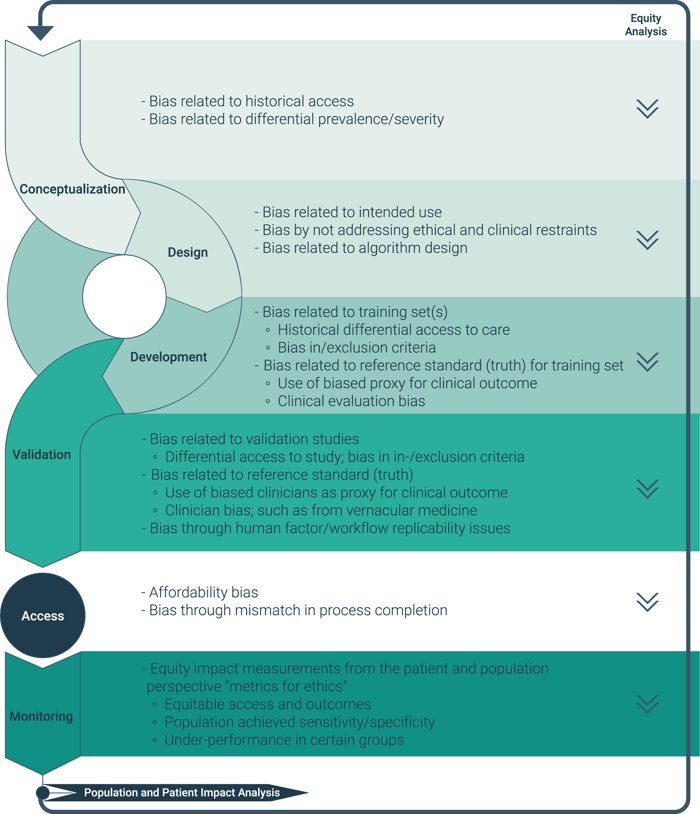

Sources of bias across the data-to-model pipeline (original course figure).

#### Selection

Who's in the data — and who's missing.

#### Measurement

How variables are defined and recorded.

#### Historical

Past inequities baked into labels.

#### Deployment

Used on a population it wasn't built for.

Models easily memorize and amplify bias — and it often surfaces only after deployment.

Cases

### Bias in Practice

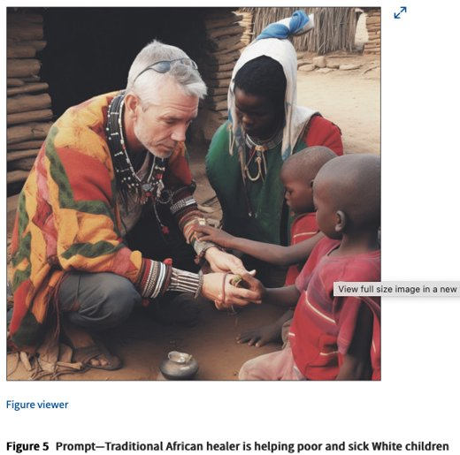

AI image generated for a prompt about a traditional African healer 'helping White children' — stereotyping in generative AI (Lancet Global Health).

#### "Stochastic Parrots" & Gebru

A landmark paper warned LLMs can reproduce bias at scale and obscure accountability — the fallout highlighted who gets to raise these concerns.

#### Generative AI bias

Generators reinforce stereotypes — over/under-representing groups and mis-depicting people and places.

Reference: Bender, Gebru et al., "On the Dangers of Stochastic Parrots" — [dl.acm.org](https://dl.acm.org/doi/10.1145/3442188.3445922). Gebru/Google: [Wired](https://www.wired.com/story/google-timnit-gebru-ai-what-really-happened/) · [Guardian](https://www.theguardian.com/lifeandstyle/2023/may/22/there-was-all-sorts-of-toxic-behaviour-timnit-gebru-on-her-sacking-by-google-ais-dangers-and-big-techs-biases). GenAI bias: [Nature](https://www.nature.com/articles/d41586-024-00674-9) · Lancet Global Health · [Wired (the paper)](https://www.wired.com/story/behind-paper-led-google-researchers-firing/) · [OpenAI: bias in DALL·E](https://openai.com/index/reducing-bias-and-improving-safety-in-dall-e-2/) · [Gebru profile](https://globalleaderstoday.online/dr-timnit-gebru-ethics-at-the-heart-of-ai/)

Mitigation

### Strategies to Reduce Bias

#### Better data

Representative sampling, document gaps, audit for missing groups.

#### Test for disparities

Evaluate performance *by subgroup*, not just on average.

#### Human & community oversight

Involve affected communities; keep a human on high-stakes calls.

"Fair on average" can still be unfair to specific neighborhoods or populations — always disaggregate.

[Stanford HAI: structural change](https://hai.stanford.edu/news/timnit-gebru-ethical-ai-requires-institutional-and-structural-change) · [Reducing bias in ML](https://encord.com/blog/reducing-bias-machine-learning/)

Part 2

## Privacy, Transparency & Accountability

Health data is sensitive, models are opaque, and someone is responsible when things go wrong.

Privacy

### Privacy & Data Security for Health Data

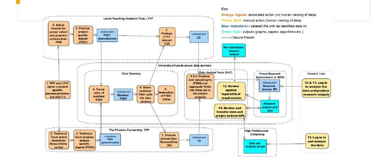

A privacy-first data flow: pseudonymization, secure data services, and a firewall between identifiable data and outputs (from my CRP workshop).

#### The rules

- HIPAA, GDPR, state privacy laws
- Informed consent for continuous & secondary use
- Unclear ownership of wearable/app data

#### Protective methods

- De-identification & data minimization
- On-device / federated processing
- Access-controlled environments

Default rule for the week: never paste protected health data into a public AI tool.

New risk

### Re-identification: "Anonymous" Isn't

#### The problem

- A few quasi-identifiers (ZIP, age, sex, dates) can re-identify individuals
- Linking datasets makes it easier
- Fine spatial detail is especially risky in small areas

#### Defenses

- Aggregate or coarsen geography and dates
- k-anonymity / differential privacy
- Assess re-identification risk before sharing

In urban health, geographic precision is both the value and the privacy risk — handle it deliberately.

Transparency

### The Black Box Problem

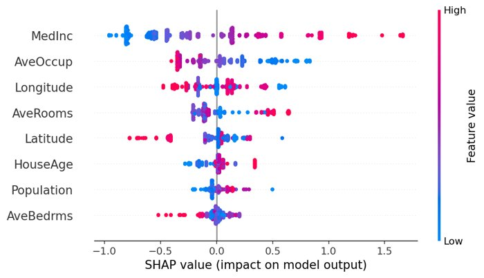

#### Why it's hard

- Deep models aren't explicitly programmed
- We can't always say *why* they decided
- Generative models aren't fully deterministic

#### Tools to peek inside

- SHAP / LIME attributions
- Attention & layer visualization
- Edge-case behavioral testing

Interpretability is essential for trust, debugging, and regulatory compliance — but it's partial, not perfect.

[SHAP: explainable AI](https://shap.readthedocs.io/en/stable/example_notebooks/overviews/An%20introduction%20to%20explainable%20AI%20with%20Shapley%20values.html)

Documentation

### Model Cards & Datasheets

#### Model card

- Intended use & out-of-scope use
- Performance — overall and by subgroup
- Known limitations & ethical considerations

#### Datasheet for a dataset

- How & why the data was collected
- Who's represented (and who isn't)
- Consent, licensing, and recommended uses

Lightweight documentation that makes a model's fitness — and its limits — explicit before anyone relies on it.

References: Mitchell et al., "Model Cards"; Gebru et al., "Datasheets for Datasets"

Accountability

### Who Is Responsible When AI Fails?

#### The chain

Developer, deployer, and user all share responsibility — "the AI did it" is not a defense.

#### It's being tested in court

Courts have begun holding companies liable for false statements their AI generates.

#### In practice

Document decisions, keep humans accountable, and disclose AI use to those affected.

As agents take real-world actions (Day 3), accountability becomes a design requirement, not an afterthought.

Copyright & fair use: [Mt. Holyoke](https://guides.mtholyoke.edu/copyright/fair-use) · [EFF: GenAI & fair use](https://www.eff.org/deeplinks/2025/06/two-courts-rule-generative-ai-and-fair-use-one-gets-it-right). Governance: [Harvard](https://corpgov.law.harvard.edu/2025/04/24/strategic-governance-of-ai-a-roadmap-for-the-future/)

Part 3

## Community Co-Design

The people affected by a system should help shape it. A worked example from our own research.

Co-design

### Why Community Input Matters

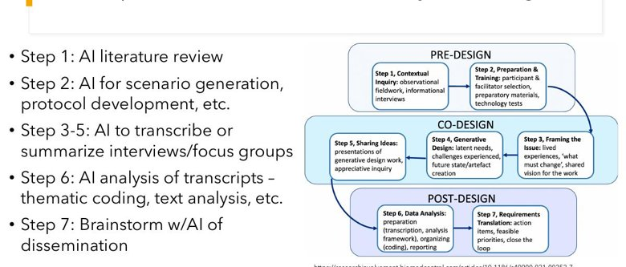

AI's role across the co-design cycle, pre-design → post-design (from my CRP workshop).

#### Why

- Surfaces local context models miss
- Builds trust and legitimacy
- Guards against harm to those meant to benefit

#### How

- Focus groups & participatory workshops
- Community advisory boards; shared decisions on data & goals

Co-design is a spectrum — from informing, to consulting, to genuinely sharing power.

Case study

## Climate Change & Health in Informal Settlements

Bogotá & Barranquilla, Colombia — combining satellite, cohort, and community data, with engagement at the center.

Context

### Climate Hazards in Two Cities

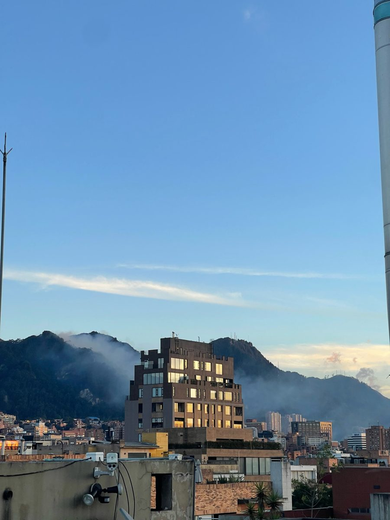

Bogotá — dense, hillside informal growth.

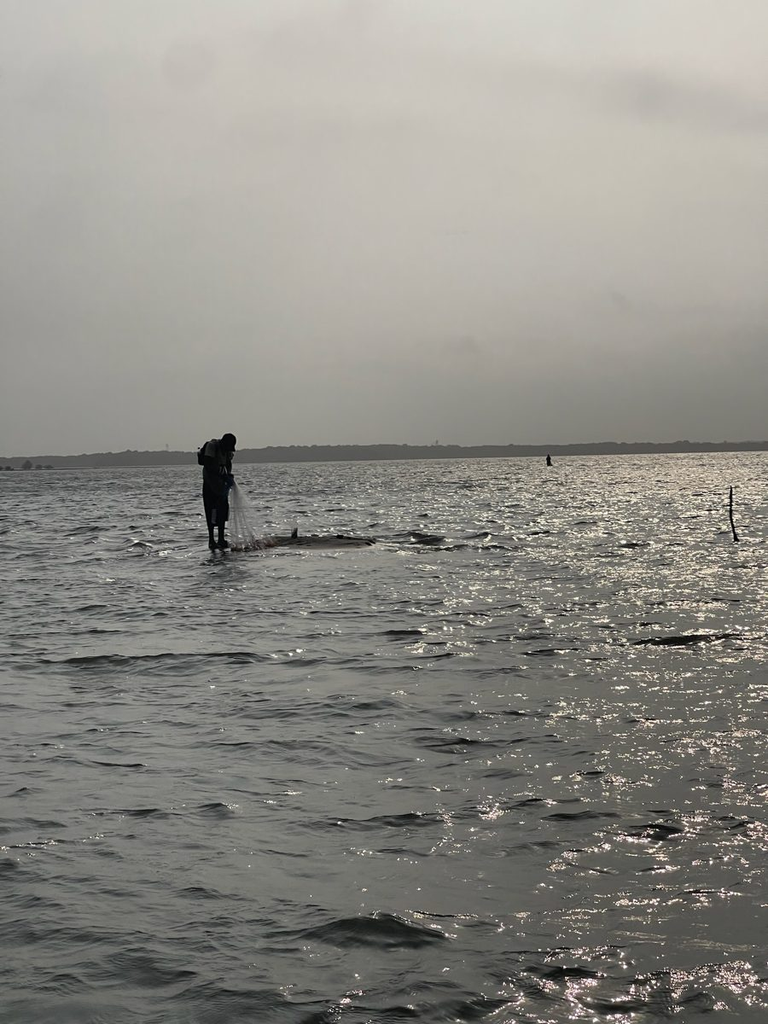

Barranquilla — coastal exposure to flooding and heat.

#### Bogotá

- High-altitude; landslides & flooding on steep, informal hillsides
- Rapid, unplanned urban growth

#### Barranquilla

- Coastal; heat, flooding, and "arroyos" (flash-flood streets)
- Exposure concentrated in informal settlements

Informal settlements face the sharpest climate-health risks and the thinnest data — a gap AI methods can help close.

Context: [Bogotá floods (El Tiempo)](https://www.eltiempo.com/bogota/lluvias-en-bogota-fuerte-granizada-e-inundaciones-en-varias-localidades-716711) · [Barranquilla (El Heraldo)](https://www.elheraldo.co/barranquilla/emergencias-por-lluvias-en-la-playa-y-las-flores-913775) · [UN-Habitat climate guide](https://unhabitat.org/sites/default/files/2020/05/climatechange_vulnerabilityandriskguide.pdf) · · [Barranquilla winds (El Heraldo)](https://www.elheraldo.co/atlantico/fuertes-vientos-dejan-emergencias-en-varios-sectores-de-barranquilla-974253) · [UN-Habitat data](https://data.unhabitat.org/pages/housing-slums-and-informal-settlements)

Methods

### Bringing Multiple Data Sources Together

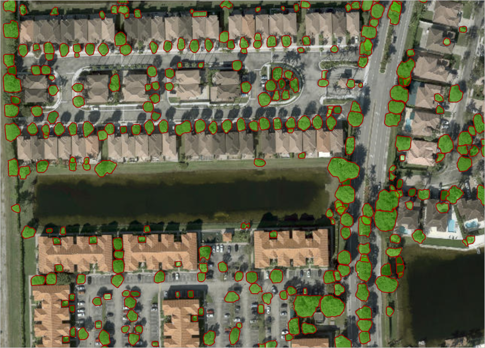

#### Satellite & building footprints

Map informal settlements and exposure using open building-footprint data.

#### Cohort & health data

Link environmental exposure to health outcomes over time.

#### Qualitative data

Focus groups and interviews ground the numbers in lived experience.

Open data: [Microsoft Global ML Building Footprints](https://github.com/microsoft/GlobalMLBuildingFootprints)

Voices

### What the Community Told Us

#### Exposure

Flooding, heat, and unsafe housing dominate daily life and health.

#### Trust & data

Concerns about how their data and images are used and shared.

#### Priorities

Residents' priorities don't always match outside assumptions.

Qualitative themes reshaped the analysis — and which questions were worth asking at all.

Participatory method: [Stanford Our Voice](https://med.stanford.edu/ourvoice.html)

Engagement

### Community Engagement in Practice

- Engage communities **before** data collection, not after results.
- Be transparent about what satellite, sensor, and survey data can and can't reveal.
- Share findings back in accessible formats; co-interpret results.
- Treat data on vulnerable communities as a responsibility, not just a resource.

The methods are technical; the legitimacy is relational. Both are required.

Part 4

## Environment & the Future

AI's benefits come with real resource costs — and a fast-changing societal landscape.

Sustainability

### AI's Environmental Footprint (2026)

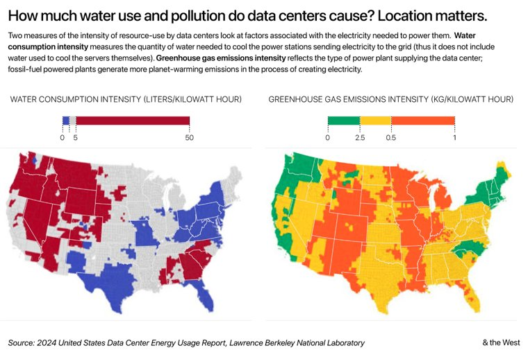

Data-center water use & emissions vary sharply by location (US DOE / LBNL).

~945 TWh

Projected global data-center electricity by 2030 (≈415 in 2024).

1.3 billion

People whose basic annual water needs AI use could equal by decade's end (UN).

10–28%

Data-center energy attributed to AI today.

Training and serving large models consumes electricity, water (cooling), and hardware materials.

Sources: IEA 2026; UN University / UN News (June 2026). Water: [Bloomberg](https://www.bloomberg.com/graphics/2025-ai-impacts-data-centers-water-data/) · [The Conversation](https://theconversation.com/we-are-ignoring-the-true-cost-of-water-guzzling-data-centres-167750) · [Business Insider](https://www.businessinsider.com/how-data-centers-are-deepening-the-water-crisis-2025-6) · [AP](https://apnews.com/article/data-centers-artificial-intelligence-technology-amazon-google-56b84cbb94942039754282afb076a87b) · [Stanford](https://andthewest.stanford.edu/2025/thirsty-for-power-and-water-ai-crunching-data-centers-sprout-across-the-west/) · [arXiv: data-center footprint](https://arxiv.org/html/2411.09786v1) · [Springer (book)](https://link.springer.com/book/10.1007/978-3-031-01761-2)

Mitigation

### Toward More Sustainable AI

#### Right-size the model

Use the smallest model that works; smaller/open models can run locally.

#### Efficient infrastructure

Liquid cooling cuts direct water use 70–90%; clean-energy siting.

#### Use it deliberately

Don't run a frontier model where a query or a script would do.

Balance the benefits against the costs — and prefer the lightest tool that solves the problem.

Looking ahead

### What Does the Future Hold?

#### Education

AI literacy as a core skill; rethinking assessment.

#### Employment

Roles change more than vanish; new skills needed.

#### Misinformation

Synthetic media erodes trust; provenance matters.

#### Misuse

Surveillance and dual-use risks need governance.

Also keep pushing on reproducibility & open science: share data, code, and model documentation so AI research can be trusted and reused.

Education: [NYT](https://www.nytimes.com/2025/05/30/technology/ai-jobs-college-graduates.html) · [Possibility literacy](https://nickpotkalitsky.substack.com/p/possibility-literacy-navigating-ais). Jobs: [McKinsey](https://www.mckinsey.com/featured-insights/future-of-work/jobs-lost-jobs-gained-what-the-future-of-work-will-mean-for-jobs-skills-and-wages). Misinfo/misuse: [deepfake scam (CNN)](https://www.cnn.com/2024/02/04/asia/deepfake-cfo-scam-hong-kong-intl-hnk) · [facial recognition (SciAm)](https://www.scientificamerican.com/article/police-facial-recognition-technology-cant-tell-black-people-apart/) · [welfare surveillance (Amnesty)](https://www.amnesty.org/en/latest/news/2024/11/denmark-ai-powered-welfare-system-fuels-mass-surveillance-and-risks-discriminating-against-marginalized-groups-report/). Open science: [Nature](https://www.nature.com/articles/s41467-024-51202-2) · [SciAm: AI in publishing](https://www.scientificamerican.com/article/chatbots-have-thoroughly-infiltrated-scientific-publishing/) · [Open & sustainable AI](https://www.themoonlight.io/en/review/open-and-sustainable-ai-challenges-opportunities-and-the-road-ahead-in-the-life-sciences) · [NY Mag: education](https://nymag.com/intelligencer/article/openai-chatgpt-ai-cheating-education-college-students-school.html) · [WEF: work](https://www.weforum.org/stories/2024/08/why-ai-will-not-lead-to-a-world-without-work/) · [NYT: chatbots & conspiracies](https://www.nytimes.com/2025/06/13/technology/chatgpt-ai-chatbots-conspiracies.html) · [Tufts: costs & risks](https://it.tufts.edu/costs-and-risks-artificial-intelligence) · [Carlini: future of AI](https://nicholas.carlini.com/writing/2025/thoughts-on-future-ai.html)

Hands-on

### Today's Activities

#### 1 · Ethical dilemma scenarios

Work through real AI-in-health dilemmas in small groups and defend a course of action.

#### 2 · Bias detection

Probe a model for biased or stereotyped outputs and discuss mitigations.

#### 3 · Privacy quick assessment

Classify data sensitivity and choose the right tool, setting, or local model.

#### 4 · Personal AI integration plan

Draft how you'll use AI responsibly in your own urban-health work.

Conclusion

## Use AI Like a Responsible Professional

Invite AI in, but stay the human in the loop. Watch for bias, protect privacy, document and disclose, involve communities, and weigh the environmental cost. Powerful tools, used with judgment — that's the whole course in one line.